# Relationship between odonates traits and their conservation

```r
library(ade4)
library(adegraphics)

library(ggplot2)
library(RColorBrewer)

library(dplyr)
library(stringr)
library(tidyr)
library(tidytext)

library(randomForest)
# install_github('munoztd0/reprtree')
library(reprtree)

library(here)

read_folder <- here("data/02_processed")

set.seed(42)
```

## 1 Summary

In this document, I investigate the link between several indices of odonates’ conservation status and their traits. Using two complementary methods, I find that species trends and area of occurrence can be reasonably related to species traits.

The most important traits are: the habitat (species preferring oligotrophic or southern streams habitats usually have a less favorable status, while eutrophic species usually have a more favorable status) and the preferred temperature (cold-adapted species and species that do not tolerate a large range of temperature usually have a less favorable status, while warm-adapted species that tolerate a large range of temperatures usually have a more favorable status).

## 2 Aim

Several odonate species are threatened, and the status of (almost) all European species is known through the red list assessment. But beyond the status of each species, is it possible to generalize these results and define some groups of species with a shared set of traits that are more vulnerable than others?

Our working hypothesis is that odonates decline is linked to several drivers (pollution, habitat destruction…), but that the impact of these pressures on a species depends on its traits.

Therefore, the protection status of odonates may provide an integrative measures of the intensity of the various pressures that affect them, and therefore be linked to their traits (without explicitly modelling the link between traits and pressures).

## 3 Questions

These analyses aim at highlighting the links between odonates traits and different markers of their conservation status, used in IUCN species assessments. Specifically, we ask:

- is a subset of (possibly correlated) traits correlated to metrics of conservation status? If yes, what are these traits?
- do different traits affect different conservation status metrics?
- which traits (if any) can predict the more accurately metrics of conservation status?

## 4 Methods

To answer these question, we test two methods:

- multivariate analyses, either discriminant analyses to predict categorical variables, or redundancy analysis to predict the continuous variable;
- random forests.

Multivariate analyses allow to quantify the direction of the relationship and to test it, but assume linearly distributed variables and a linear response, whereas random forests don’t make any assumption on data distribution or the shape of the relationship, but don’t give the direction of the relationship and don’t provide a test.

## 5 Data

We use a compiled database of odonate species (thanks Geert!), containing various morphological, behavioral and life history traits:

- `body_size`: a synthetic variable (obtained by PCA) summarizing various morphological metrics
- `habitat`: the preferred habitat of a species
- `tmean`: mean temperature over the area of distribution of the species
- `tsd`: standard deviation of temperature over the area of distribution of the species
- `flight_start`: month the adults start flying (higher = later)
- `flight_length`: length of the adults flying period (months)
- `darkness`: species coloration (higher = darker)
- `voltinism`: species voltinism (number of generations per year: higher values are assocuated to multivoltine species)
- `percher`: whether the species is more a percher (high values) or a flier
- `winter`: overwintering status of the species (higher = closer to adult)
- `larva_strat`: larval strategy
- `oviposition`: oviposition substrate

We relate these traits to the following 4 measures of conservation:

- `status`: UICN category, as assessed by the 2024 European red list
- `binary_status`: UICN category, simplified into threatened or non-threatened (more information in Section 7.2)
- `trend`: trend of the species (population or distribution trend)
- `area`: area of occupancy of the species (sum of 2x2 km$^2$ squares occupied in Europe)

### 5.1 Read & prepare data

```r
df <- readRDS(file.path(read_folder,
                        "taxo_traits.rds"))
```

```r
# Rename columns
newnames <- c("body_size" = "Body_size_PCA",
              "habitat" = "habitattype",
              "tmean" = "STI",
              "tsd" = "SD",
              "flight_start" = "start_main_flight_period",
              "flight_length" = "flight_period_length",
              "darkness" = "Coloration_class",
              "percher" = "Perchers_and_fliers",
              "winter" = "Overwintering_stage",
              "larva_strat" = "Larval_strategy",
              "oviposition" = "Oviposition_substrate",
              "status" = "ERL_2024_category",
              "trend" = "Population_trend",
              "binary_status" = "Conservation",
              "area" = "AOO_Europe")

df <- df |>
  rename(all_of(newnames))
```

```r
# Recode habitat levels
df$habitat <- as.character(df$habitat)

df$habitat[df$habitat == "temporary waters"] <- "temp_water"
df$habitat[df$habitat == "southern Streams and rivers"] <- "southern_streams"
df$habitat[df$habitat == "streams and rivers"] <- "streams"

df$habitat <- factor(df$habitat)
# levels(df$habitat)
```

Here, we choose to include as many traits as possible in the analysis, but exclude data relative to taxonomy, intermediate variables encompassed in other measures (e.g. No_squares or morphological variables related to body size) and conservation status (because we want to predict these).

```r
# Select data
df_relevant <- df |>
  select(body_size,
         habitat,
         tmean, tsd, # to update + an aridity index will be added
         flight_start,
         flight_length,
         # dispersion,
         darkness,
         voltinism,
         percher,
         winter,
         larva_strat,
         oviposition)
# add average latitude + sd
```

We fuzzy-code the following ordered categorical variables:

```r
# Fuzzy-coding
df_relevant |>
  select(where(is.ordered)) |>
  colnames()
```

```
[1] "darkness"  "voltinism" "percher"   "winter"
```

```r
df_fuzzy <- df_relevant |>
  mutate(across(where(is.ordered), as.numeric))
```

```r
# Remove NAs
df_mvar <- na.omit(df_fuzzy)
```

```r
# Select the rows of the full dataframe present in the analysis
ind <- na.omit(match(rownames(df_mvar), rownames(df)))
df_fac <- df[ind, ]

# Recode category and status to exclude level DD
df_fac$status <- factor(df_fac$status,
                        levels = unique(df_fac$status))

df_fac$binary_status <- factor(df_fac$binary_status,
                               levels = unique(df_fac$binary_status))
```

### 5.2 Data summary

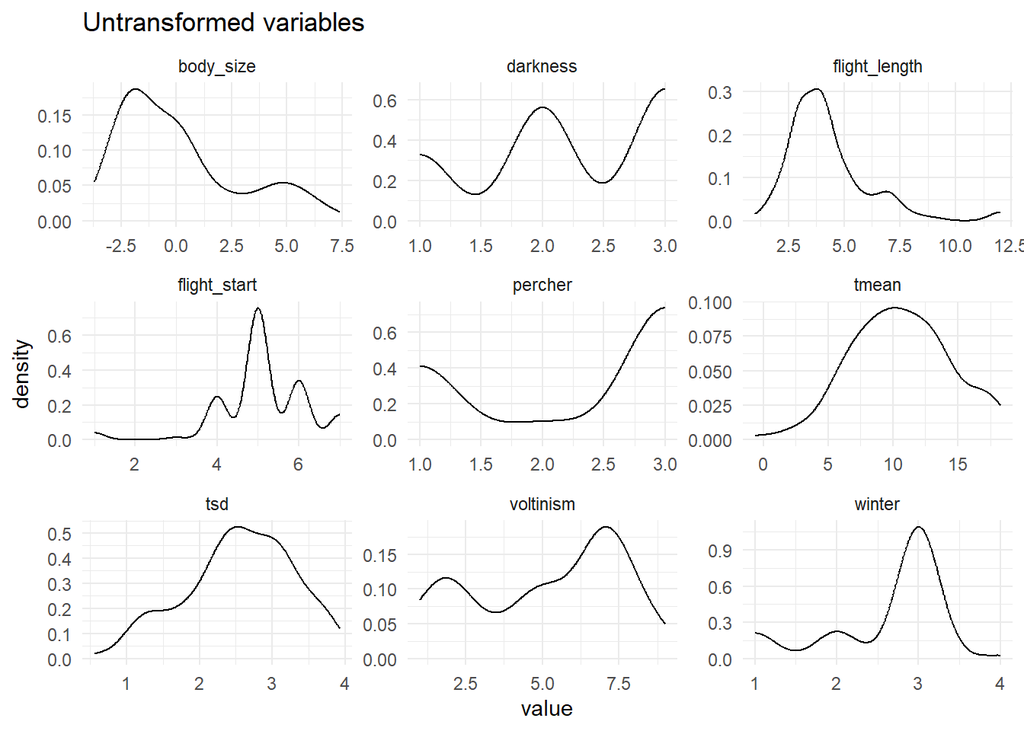

```r
# Visually inspect normality
df_num <- df_mvar |>
  select(where(is.numeric)) |>
  pivot_longer(cols = everything())

ggplot(df_num) +
  facet_wrap(facets = vars(name), scales = "free") +
  geom_density(aes(x = value)) +
  theme_minimal() +
  ggtitle("Untransformed variables")
```

```r
# Log-transform some variables
df_mvar <- df_mvar |>
  mutate(flight_length = log(flight_length),
         body_size = log(body_size + abs(min(body_size)) + 0.00001))
```

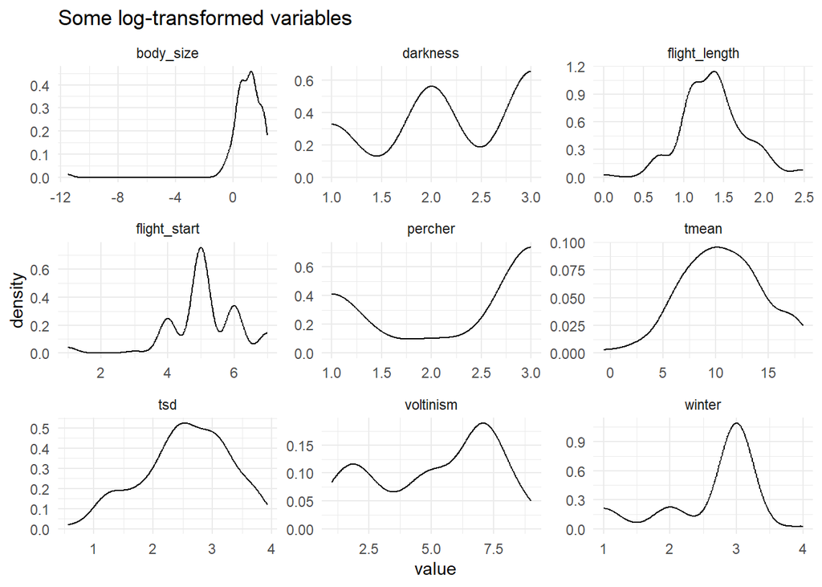

```r
# Visually inspect normality of transformed variables
df_num <- df_mvar |>
  select(where(is.numeric)) |>
  pivot_longer(cols = everything())

ggplot(df_num) +
  facet_wrap(facets = vars(name), scales = "free") +
  geom_density(aes(x = value)) +
  theme_minimal() +
  ggtitle("Some log-transformed variables")
```

```r
summary(df_mvar)
```

```
   body_size                    habitat       tmean              tsd
 Min.   :-11.5129   eutrophic       :46   Min.   :-0.6357   Min.   :0.5619
 1st Qu.:  0.4904   generalist      :10   1st Qu.: 7.7552   1st Qu.:2.1628
 Median :  1.1946   oligotrophic    :16   Median :10.4300   Median :2.5761
 Mean   :  0.9845   southern_streams:25   Mean   :10.6177   Mean   :2.5519
 3rd Qu.:  1.5998   streams         :12   3rd Qu.:13.3178   3rd Qu.:3.0664
 Max.   :  2.4058   temp_water      : 9   Max.   :18.2777   Max.   :3.9219
  flight_start   flight_length      darkness       voltinism
 Min.   :1.000   Min.   :0.000   Min.   :1.000   Min.   :1.000
 1st Qu.:5.000   1st Qu.:1.099   1st Qu.:2.000   1st Qu.:2.000
 Median :5.000   Median :1.386   Median :2.000   Median :5.000
 Mean   :5.127   Mean   :1.373   Mean   :2.212   Mean   :5.119
 3rd Qu.:6.000   3rd Qu.:1.609   3rd Qu.:3.000   3rd Qu.:7.000
 Max.   :7.000   Max.   :2.485   Max.   :3.000   Max.   :9.000
    percher          winter        larva_strat     oviposition
 Min.   :1.000   Min.   :1.000   burrower:17   endophytic:56
 1st Qu.:1.000   1st Qu.:2.000   claspers:19   exophytic :56
 Median :3.000   Median :3.000   hider   :22   sediment  : 6
 Mean   :2.263   Mean   :2.602   sprawler:60
 3rd Qu.:3.000   3rd Qu.:3.000
 Max.   :3.000   Max.   :4.000
```

## 6 Hill-Smith analysis

This first analysis is very exploratory, and aims at describing the main axes of variation of species traits (and it is also the first step for the following discriminant analyses). More specifically, we ask:

- which suite of traits determines the main axes of variation in the odonates functional space?
- how are these traits correlated?

For that, we perform a Hill-Smith analysis, which is a principal component analysis that allows factor variables.

```r
# Hill-Smith (PCA extended to include factors)
mvar <- dudi.hillsmith(df_mvar, nf = 2,
                       scannf = FALSE)
```

Below are the part of variation explained by the axes:

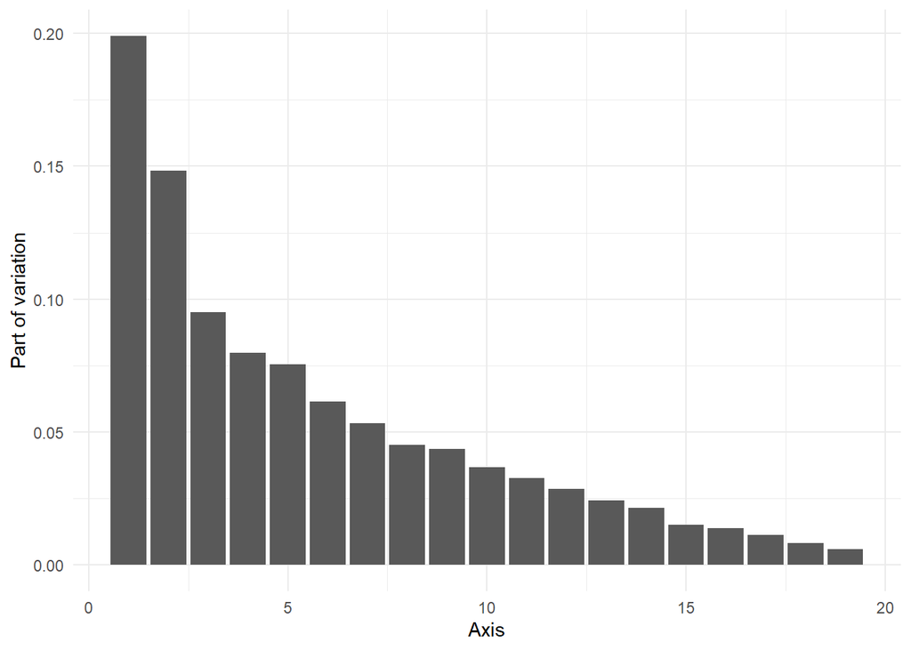

```r
ggplot() +
  geom_col(aes(y = mvar$eig/sum(mvar$eig),
               x = 1:length(mvar$eig))) +
  xlab("Axis") +
  ylab("Part of variation") +
  theme_minimal()
```

```r
(pvar <- sum(mvar$eig[1:2])/sum(mvar$eig)*100)
```

```
[1] 34.72444
```

For the following, we concentrate on the first two axes which describe 34.72% of variation.

The graphs below summarize the relationship between traits and axes of variation:

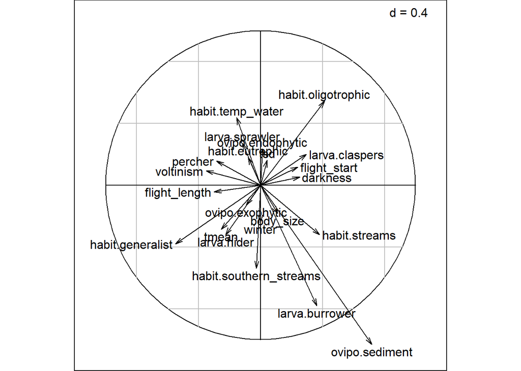

```r
s.corcircle(mvar$c1*0.8,
            plabels.boxes.draw = FALSE)
```

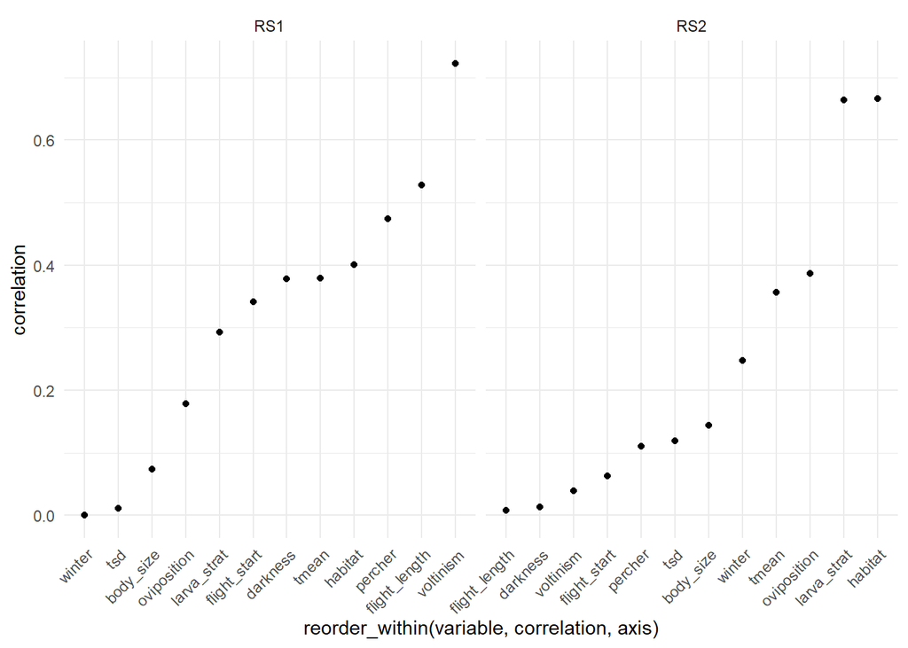

```r
corvar <- mvar$cr
corvar <- data.frame(corvar)
corvar$variable <- rownames(mvar$cr)
corvar <- corvar |>
  pivot_longer(cols = starts_with("RS"),
               names_to = "axis",
               values_to = "correlation")

ggplot(corvar) +
  facet_wrap(facet = vars(axis), scales = "free_x") +
  geom_point(aes(x = reorder_within(variable,
                                    correlation,
                                    axis),
                 y = correlation)) +
  scale_x_reordered() +
  theme_minimal() +
  theme(axis.text.x = element_text(angle = 45, hjust = 1))
```

The first axis is driven by voltinism, length of the flight period and perching behavior. It opposes:

- multivoltine, long flight period, percher species (left);
- to partivoltine, short flight period, flier species (right).

The second axis is driven by habitat and larval strategy, and to a lesser extent oviposition and mean temperature. It opposes:

- oligotrophic, temporary water or eutrophic species (i.e. lentic water species) whose larvae are sprawlers or claspers, living in cold environments and performing endophytic oviposition (top);
- to (southern) streams and generalist species (lotic water species) with hider and burrower larvae, living in warm environments and performing sediment oviposition (bottom).

Below are species in the factorial plane.

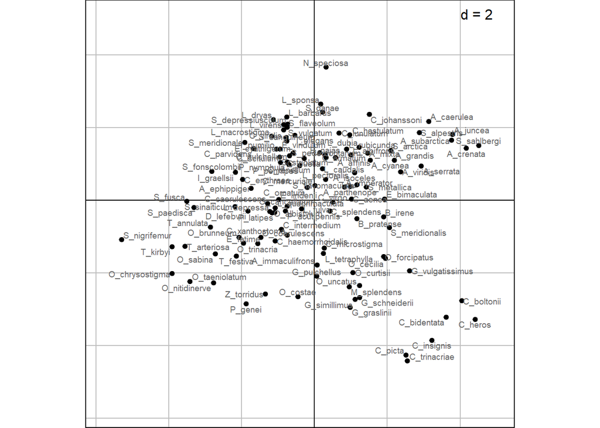

```r
s.label(mvar$li,
        labels = rownames(df_mvar),
        plabels.col = "grey40",
        plabels.cex = 0.6,
        plabels.optim = TRUE)
```

Below, we examine how the different taxonomic groups map onto trait variation.

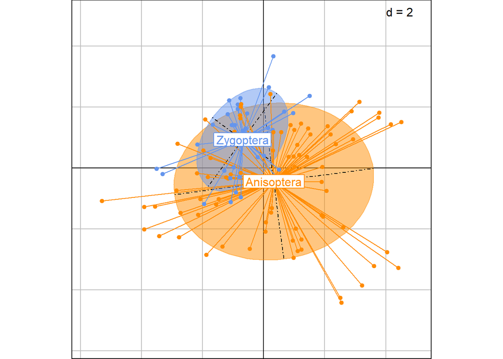

```r
# Taxonomic classes
s.class(mvar$li,
        fac = df_fac$Suborder,
        col = c("darkorange", "cornflowerblue"))
```

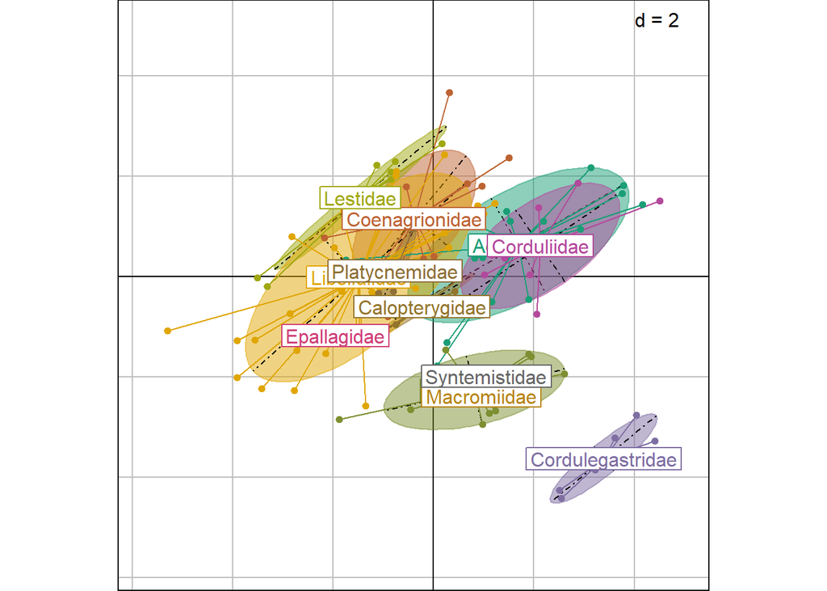

```r
nfam <- length(levels(df_fac$Family))
pal_fam <- colorRampPalette( brewer.pal(8, "Dark2") )(nfam)
s.class(mvar$li,
        fac = df_fac$Family,
        col = pal_fam)
```

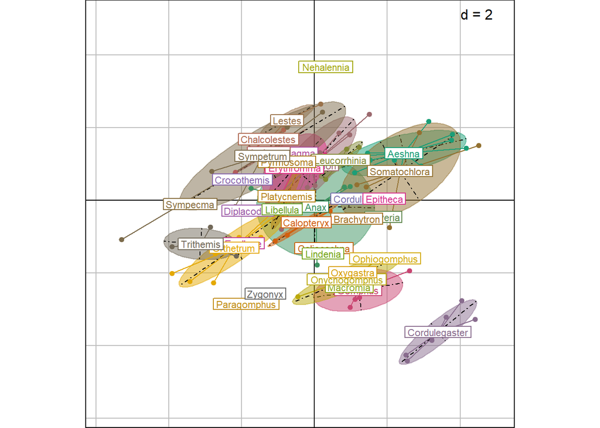

```r
ngen <- length(levels(df_fac$Genus))
pal_gen <- colorRampPalette( brewer.pal(8, "Dark2") )(ngen)
s.class(mvar$li,
        fac = df_fac$Genus,
        plabels.cex = 0.7,
        col = pal_gen)
```

Species position on the multivariate plane seem to be well-related to their family (e.g. see Cordulegastridae in the bottom-right corner), which suggests a phylogenetic signal (that was expected).

We can also notice that damselflies (Zygoptera) take up a smaller part of the trait space than dragonflies (Anispotera), i.e. they tend to be less functionally diverse.

Next, we also look at how our 3 conservation metrics (status, trend and area of occupancy) map onto this functional diversity.

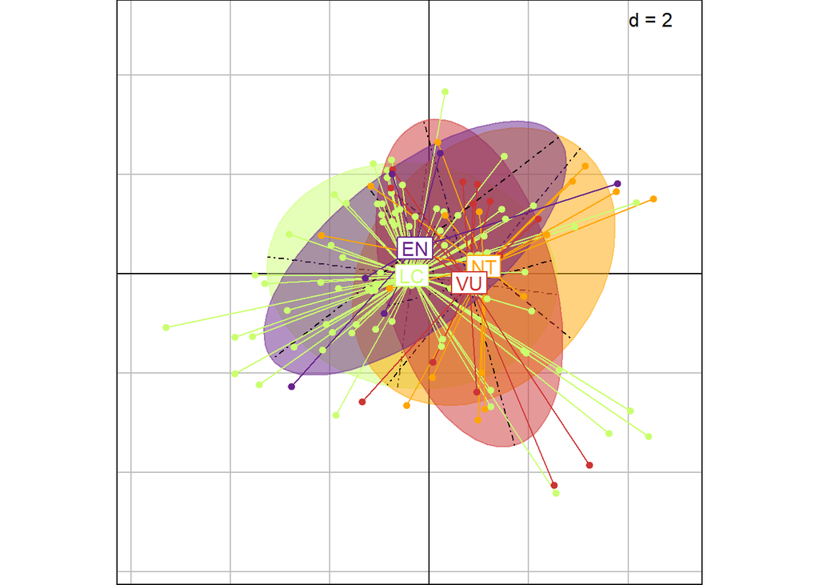

```r
# Status
col_status <- c("darkolivegreen1", "orange",
                 "brown3", "darkorchid4")
s.class(mvar$li,
        fac = df_fac$status,
        col = col_status)
```

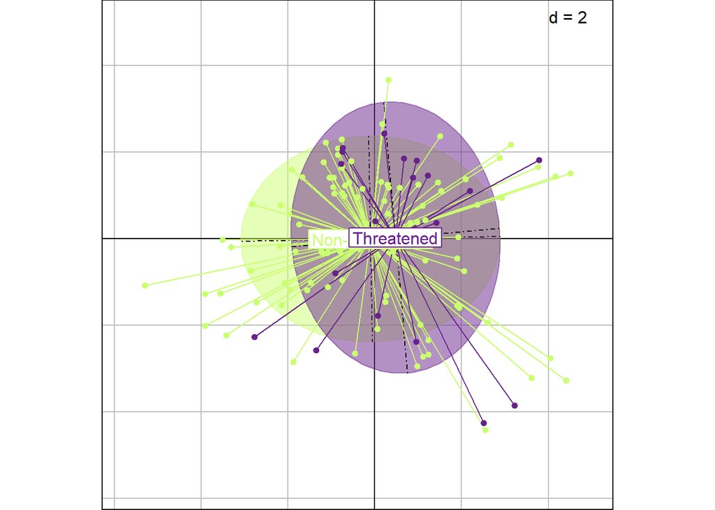

```r
# Binary status
col_bstatus <- c("darkolivegreen1", "darkorchid4")
s.class(mvar$li,
        fac = df_fac$binary_status,
        col = col_bstatus)
```

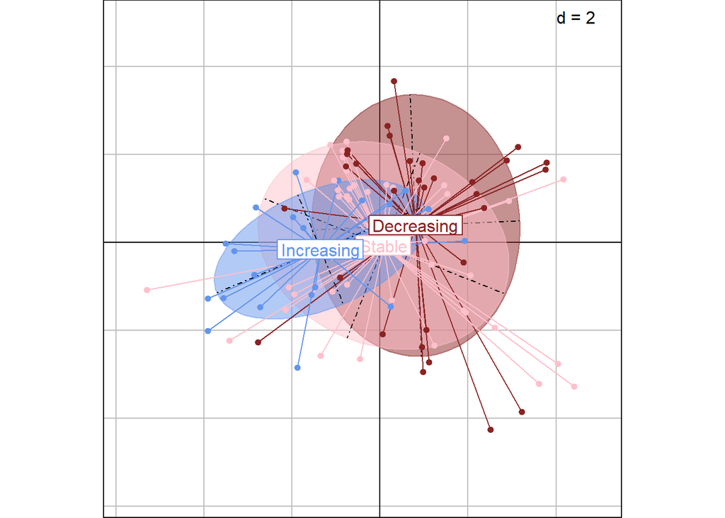

```r
# Trend
col_trend <- c("brown4", "pink", "cornflowerblue")
s.class(mvar$li,
        fac = df_fac$trend,
        col = col_trend)
```

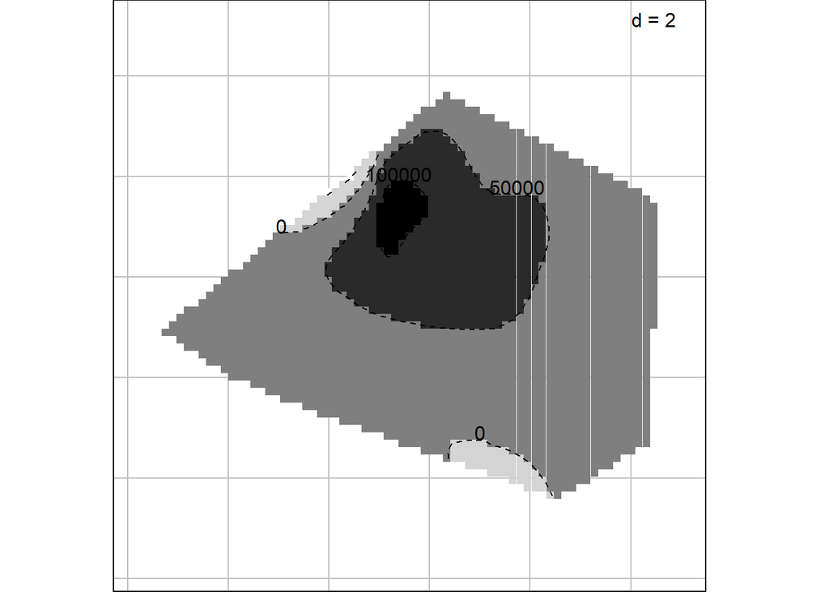

```r
# Area of occupancy
s.image(mvar$li,
        df_fac$area)
```

Regarding these conservation metrics:

- it seems that the status is not different for species with different traits, as any part of the trait space can contain threatened or least concern species.
- there is a weak tendency for species with an increasing trend to be located in the bottom left of the space (i.e. multivoltine, long flying, percher species from lotic and warm environments). Stable and decreasing species are more spread out.
- species at the bottom of the plot, i.e. species inhabiting lotic and and warm environments, tend to have the smaller areas of occurrence.

In the analysis above, traits axes were chosen to spread out species as much as possible, and not to distinguish conservation metrics: with the analyses below, we constrain the trait space to best separate the different conservation metrics instead.

## 7 Multivariate analyses

### 7.1 Red list status

First, we perform a discriminant analysis of the conservation status of species with their traits. This analysis finds the trait space that best separates the different conservation categories.

```r
if (any(is.na(df_fac$status))) {
  warning("Some status are NA")
}

discri <- discrimin(mvar,
                    fac = factor(df_fac$status),
                    scannf = FALSE, nf = 3)
```

```r
(perc <- sum(discri$eig)/sum(mvar$eig)*100)
```

```
[1] 2.954168
```

The red list status explains 2.95 % of variation in the trait space. It is not much: the variation in traits that allows to explain conservation status is only marginal. It is somewhat expected, since traits evolve in response to other variables than the ones affecting conservation status.

More interesting than the explained part of variation: let’s see how well traits succeed to separate conservation status.

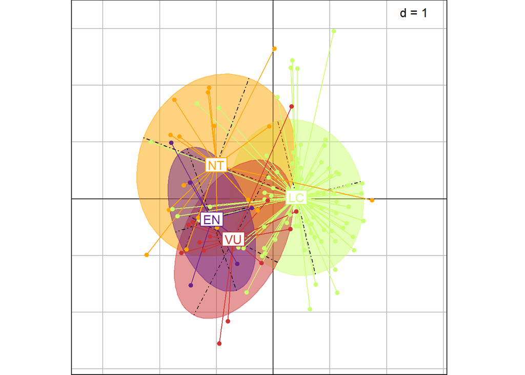

```r
s.class(discri$li,
        fac = df_fac$status,
        col = col_status)
```

The categories are rather mixed, with endangered and vulnerable species rather in the bottom-left corner, while nearly threatened species are more in the top-left corner and least concern species take up the right part of the space.

The test below allows to test the significativity of this relationship:

```r
rtest(discri, nrepet = 999)
```

```
Monte-Carlo test
Call: rtest.discrimin(xtest = discri, nrepet = 999)

Observation: 0.02954168

Based on 999 replicates
Simulated p-value: 0.205
Alternative hypothesis: greater

     Std.Obs  Expectation     Variance
8.159974e-01 2.579183e-02 2.111787e-05
```

Here, at a risk $\alpha = 5 \%$, we can say that the categories are not significantly discriminated by traits.

```r
ax2 <- sum(discri$eig[1:2])/sum(discri$eig)*100
```

We explore the relationship between the first two axes (88.56 % of variation) and variables below:

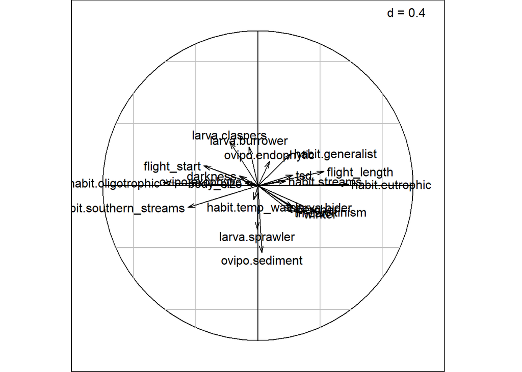

```r
s.corcircle(discri$va,
            plabels.boxes.draw = FALSE)
```

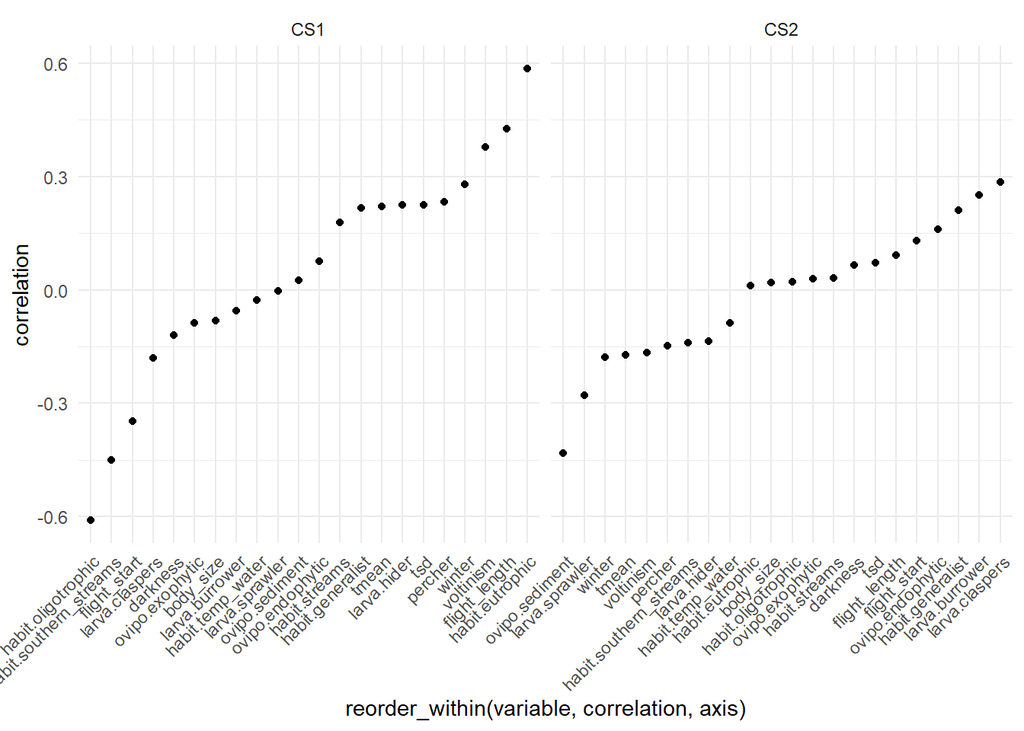

```r
corvar <- discri$va # cosines between variables and canonical scores -> Pearson correlation when vectors are centered

corvar <- data.frame(corvar)
corvar$variable <- rownames(discri$va)
corvar <- corvar |>
  select(-CS3) |>
  pivot_longer(cols = starts_with("CS"),
               names_to = "axis",
               values_to = "correlation")

ggplot(corvar) +
  facet_wrap(facet = vars(axis), scales = "free_x",
             ncol = 2) +
  geom_point(aes(x = reorder_within(variable,
                                    correlation,
                                    axis),
                 y = correlation)) +
  theme_minimal() +
  scale_x_reordered() +
  theme(axis.text.x = element_text(angle = 45, hjust = 1))
```

Axis 1 opposes:

- oligotrophic, southern streams, late and short flight, partivoltine species (left);
- to eutrophic, early and long flight, multivoltine species (right).

Axis 2 opposes:

- species with sediment oviposition and sprawler larvae (bottom);
- to species with claspers or burrowers larvae that are generalist (top).

Coming back to the position of each status in the trait space:

- least concern species are generally eutrophic, early and long flight, multivoltine species;
- nearly threatened species are generally late and short flight, partivoltine species, claspers or burrowers larvae that are generalist;
- endangered and vulnerable species are generally late and short flight, partivoltine species, performing sediment oviposition and having sprawler larvae.

The graph below shows how unconstrained axes are related to constrained axes.

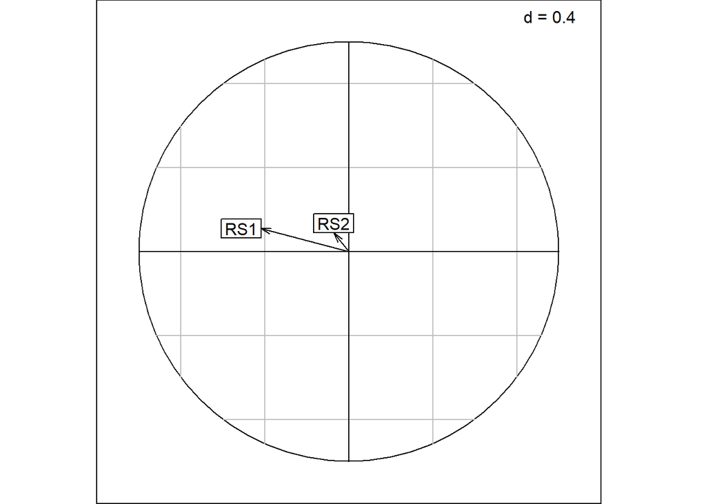

```r
s.corcircle(discri$cp[1:2, ],
            xax = 1, yax = 2)
```

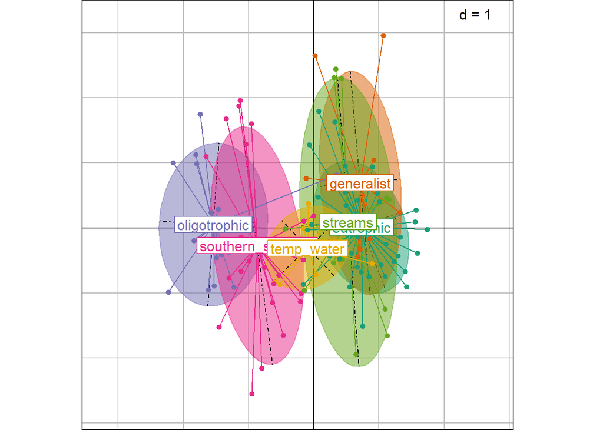

```r
col_habitat <- brewer.pal(length(levels(df_fac$habitat)),
                         "Dark2")
s.class(discri$li,
        fac = df_fac$habitat,
        col = col_habitat)
```

Finally, the graph above shows how habitat categories map almost perfectly onto the first axis. It also visually confirms that oligotrophic species tend to be threatened, while eutrophic or generalist species generally do better.

### 7.2 Binary status

To go deeper in the analysis above, we re-examine the link between traits and protection status, discriminating only between threatened (VU + EN) and non-threatened (LC + NT) species (NB: these grouped categories are used by IUCN).

```r
if (any(is.na(df_fac$binary_status))) {
  warning("Some status are NA")
}

discri <- discrimin(mvar,
                    fac = factor(df_fac$binary_status),
                    scannf = FALSE, nf = 2)
```

```r
(perc <- sum(discri$eig)/sum(mvar$eig)*100)
```

```
[1] 1.1107
```

The binary red list status explains 1.11 % of variation in the trait space (it is even less than non-binary status).

Let’s test the significativity of the relationship between traits on binary status:

```r
rtest(discri, nrepet = 999)
```

```
Monte-Carlo test
Call: rtest.discrimin(xtest = discri, nrepet = 999)

Observation: 0.011107

Based on 999 replicates
Simulated p-value: 0.144
Alternative hypothesis: greater

     Std.Obs  Expectation     Variance
1.003491e+00 8.549395e-03 6.495929e-06
```

Here, at a risk $\alpha = 5 \%$, we can say that the binary categories are not significantly discriminated by traits.

We explore the relationship between the unique discriminant axis axis and the traits below:

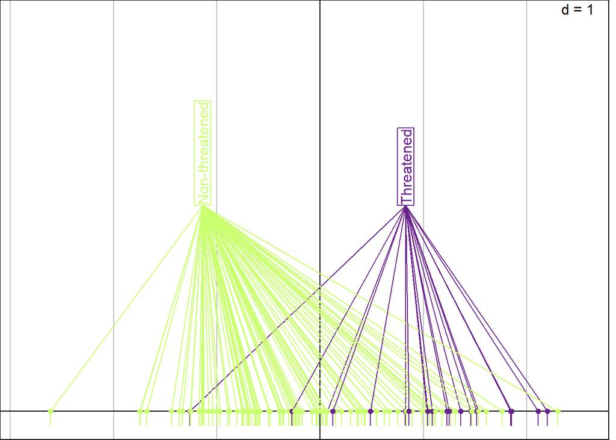

```r
s1d.class(score = discri$li,
          fac = factor(df_fac$binary_status),
          col = col_bstatus)
```

Non-threatened species generally take up the left, and threatened species the right part of the axis.

One of the threatened species has traits closer to non-threatened species.

```r
thr <- which(df_fac$binary_status == "Threatened")
rownames(discri$li)[which(discri$li == min(discri$li[thr,]))]
```

```
[1] "A_grandis"
```

```r
as.character(df_fac["A_grandis",]$Species_name)
```

```
[1] "Aeshna grandis"
```

This is *Aeshna grandis*, a Northern Europe species.

Let’s look at the variables defining this axis:

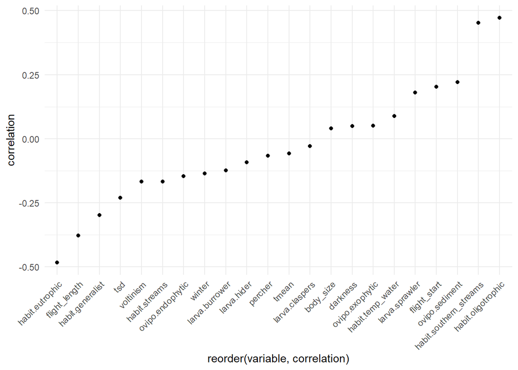

```r
corvar <- discri$va # cosines between variables and canonical scores -> Pearson correlation when vectors are centered

corvar <- data.frame(corvar)
corvar$variable <- rownames(discri$va)
corvar <- corvar |>
  pivot_longer(cols = starts_with("CS"),
               names_to = "axis",
               values_to = "correlation")

ggplot(corvar) +
  geom_point(aes(x = reorder(variable,
                             correlation),
                 y = correlation)) +
  theme_minimal() +
  theme(axis.text.x = element_text(angle = 45, hjust = 1))
```

The discriminant axis opposes:

- eutrophic, long and early flight, generalist species with a high temperature variability (left = non-threatened);
- to oligotrophic, southern streams, sediment oviposition, short and late flight, sprawler larvae (right = threatened).

### 7.3 Trend

Now, let’s examine the relationship between traits and estimated population trends.

```r
# Select subset of non-NA data
any(is.na(df_fac$trend))
```

```
[1] TRUE
```

```r
trend_ind <- which(!is.na(df_fac$trend))

df_trend <- df_mvar[trend_ind, ]
df_fac_trend <- df_fac[trend_ind,]

mvar_trend <- dudi.hillsmith(df_trend,
                             scannf = FALSE, nf = 2)
```

```r
discri <- discrimin(mvar_trend,
                    fac = df_fac_trend$trend,
                    scannf = FALSE, nf = 2)
```

```r
(perc <- sum(discri$eig)/sum(mvar_trend$eig)*100)
```

```
[1] 4.359725
```

Species trend explains 4.36 % of variation in the trait space. We test this relationship below:

```r
rtest(discri, nrepet = 999)
```

```
Monte-Carlo test
Call: rtest.discrimin(xtest = discri, nrepet = 999)

Observation: 0.04359725

Based on 999 replicates
Simulated p-value: 0.001
Alternative hypothesis: greater

     Std.Obs  Expectation     Variance
7.309756e+00 1.773804e-02 1.251482e-05
```

Here, at a risk $\alpha = 5 \%$, trends are discriminated by traits.

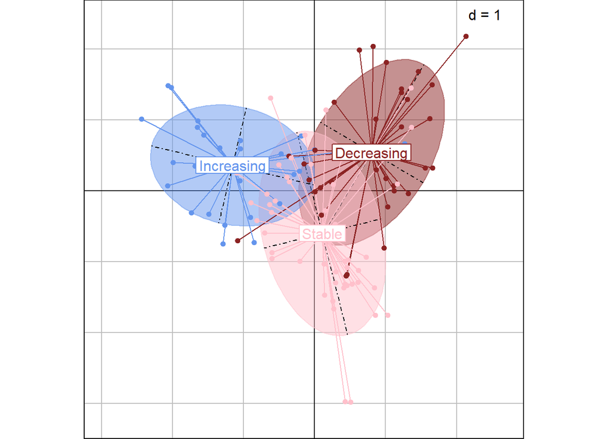

```r
s.class(discri$li,
        fac = df_fac_trend$trend,
        col = col_trend)
```

Indeed, the trends are well-separated in the traits space, with increasing species in the top-left, stable species in the bottom-middle and decreasing species in the top right.

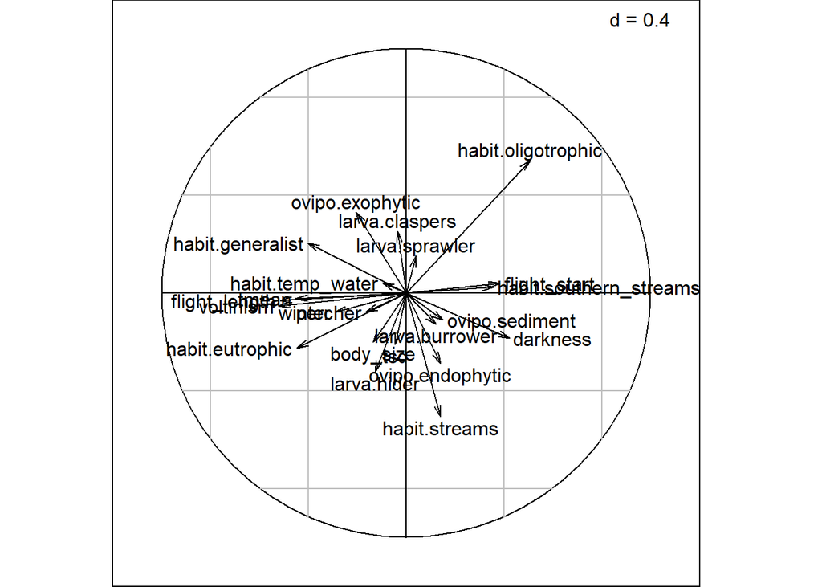

```r
s.corcircle(discri$va,
            plabels.boxes.draw = FALSE)
```

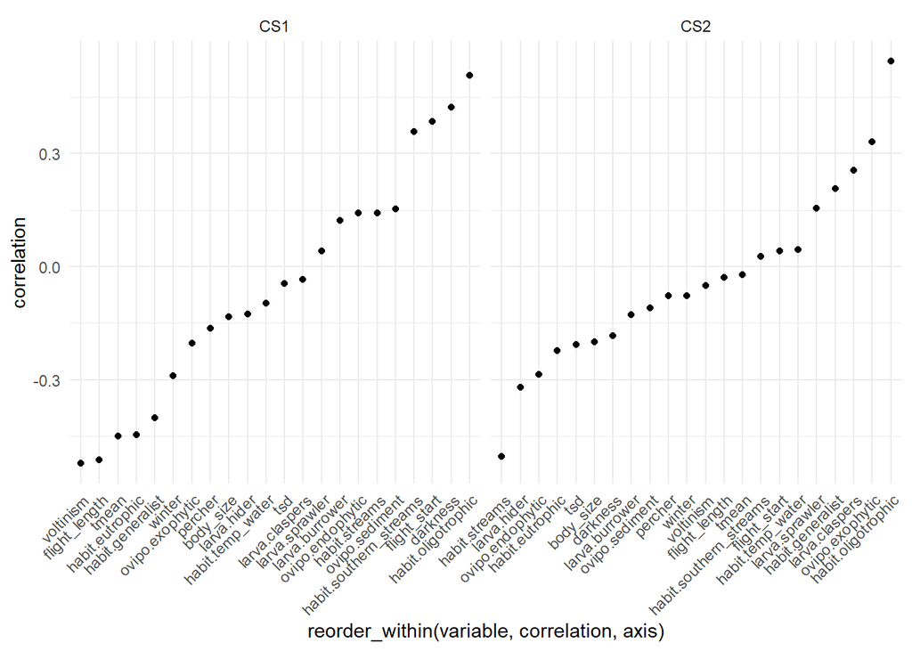

```r
corvar <- discri$va # cosines between variables and canonical scores -> Pearson correlation when vectors are centered

corvar <- data.frame(corvar)
corvar$variable <- rownames(discri$va)
corvar <- corvar |>
  pivot_longer(cols = starts_with("CS"),
               names_to = "axis",
               values_to = "correlation")

ggplot(corvar) +
  facet_wrap(facet = vars(axis), scales = "free_x") +
  geom_point(aes(x = reorder_within(variable,
                                    correlation,
                                    axis),
                 y = correlation)) +
  scale_x_reordered() +
  theme_minimal() +
  theme(axis.text.x = element_text(angle = 45, hjust = 1))
```

Axis 1 opposes:

- multivoltine, light, long and early flight, warm-adapted, eutrophic, generalist species overwintering as adults (left);
- to partivoltine, oligotrophic, dark, short and late flight, cold-adapted, southern streams species overwintering as eggs that perform oviposition in sediments (right).

Axis 2 opposes:

- streams species with hider larvae, performing endophytic oviposition (bottom);
- to oligotrophic or generalist species, with claspers or sprawlers larvae, performing exophytic oviposition (top).

To sum up:

- increasing species tend to be multivoltine, light species, with long and early flight, that are eutrophic and generalist and prefer warm environments;
- stable species tend to have a medium voltinism, be medium dark, prefer medium temperature and live in streams;
- decreasing species tend to be partivoltine, live in oligotrophic habitats or southern streams, be dark, short and late flights species and prefer cold environments.

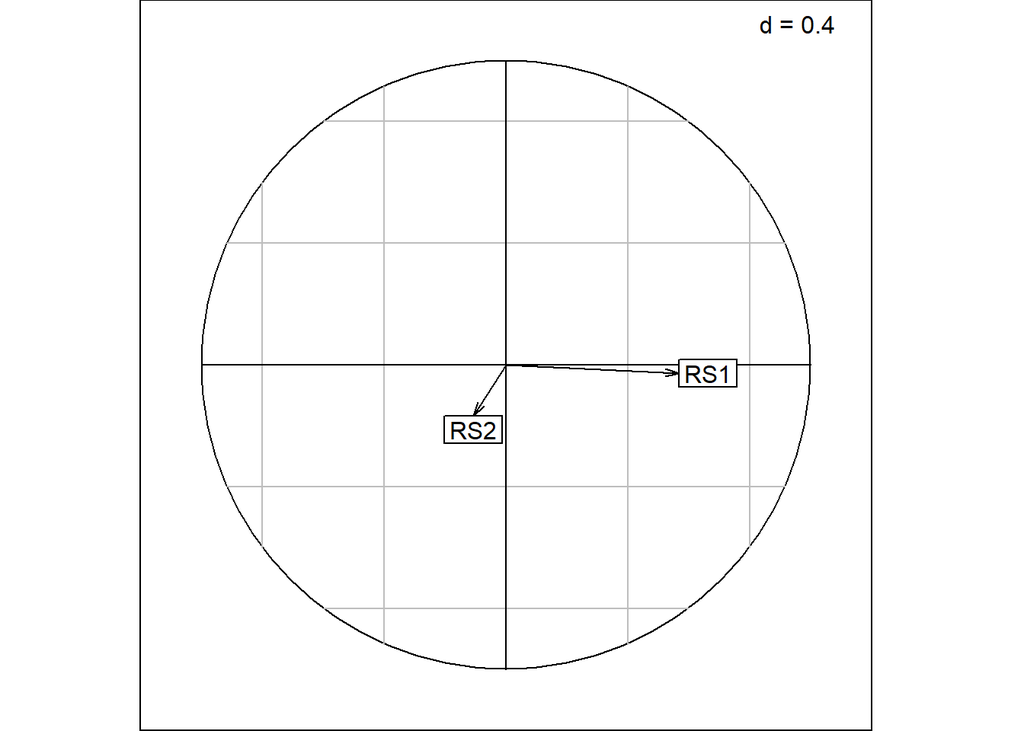

```r
s.corcircle(discri$cp[1:2, ])
```

The first discriminant axis is positively correlated to the Hill-Smith first axis and the second discriminant axis is negatively correlated to the Hill-Smith second axis.

### 7.4 Area of occupancy

For this third analysis, we perform a redundancy analysis because the response variable (`area`) is continuous. The aim is to find the best linear combination of species traits (explanatory variables) to explain the area of occupancy (response).

```r
rda <- pcaiv(mvar, df_fac$area,
             scannf = FALSE, nf = 1)
```

```r
(perc <- rda$eig/sum(mvar$eig)*100)
```

```
[1] 3.925767
```

The area of occupancy explains 3.93 % of variation in the trait space.

```r
randtest(rda, nrepet = 999)
```

```
Monte-Carlo test
Call: randtest.pcaiv(xtest = rda, nrepet = 999)

Observation: 0.03925767

Based on 999 replicates
Simulated p-value: 0.001
Alternative hypothesis: greater

     Std.Obs  Expectation     Variance
8.913135e+00 8.598917e-03 1.183172e-05
```

This relationship is significant at a risk $\alpha = 5 \%$.

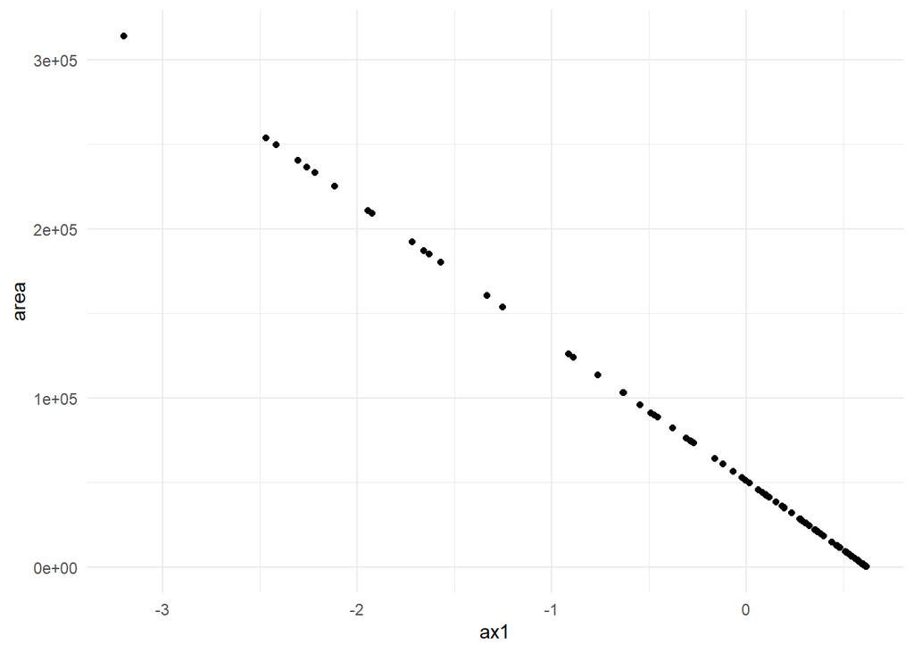

```r
df_plot <- data.frame(ax1 = rda$li$Axis1, area = df_fac$area)

ggplot(df_plot) +
  geom_point(aes(x = ax1, y = area)) +
  theme_minimal()
```

The area of occupancy is negatively correlated to the RDA axis.

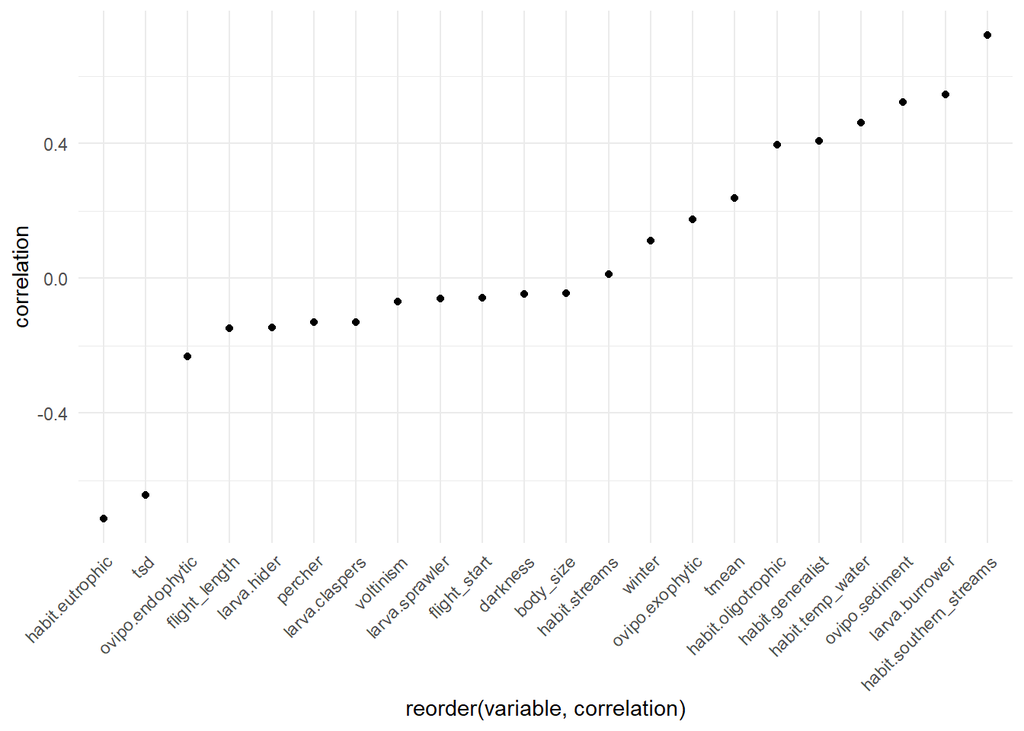

```r
corvar <- rda$c1
corvar <- data.frame(corvar)
corvar$variable <- rownames(rda$c1)

corvar <- corvar |>
  pivot_longer(cols = starts_with("CS"),
               names_to = "axis",
               values_to = "correlation")

ggplot(corvar) +
  geom_point(aes(x = reorder(variable,
                             correlation),
                 y = correlation)) +
  theme_minimal() +
  theme(axis.text.x = element_text(angle = 45, hjust = 1))
```

This axis opposes:

- eutrophic species that tolerate a large range of temperatures (left = large area of occupancy);
- to southern streams, temporary water, generalist or oligotrophic species, with burrower larvae that have a sediment oviposition and tolerate a narrow range of temperatures (right = small area of occupancy).

The high temperature variability associated to larger area of occupancy is expected, because the bigger the area of occupancy, the larger we expect the variability of temperatures in the area simply by sampling effect.

### 7.5 Summary of multivariate analyses

Only species trends and area of occupancy are discriminated by traits at a significant threshold.

However, we still discuss the relationship between traits and binary conservation status below:

- non-threatened species tend to be eutrophic, long and early flight, generalist species adapted to a large range of temperature;
- threatened species tend to be oligotrophic or southern streams species, performing sediment oviposition, having short and late flight and sprawler larvae adanted to a narrow range of temperatures.

Regarding trends:

- increasing species tend to be multivoltine, light species, with long and early flight, that are eutrophic or generalist and prefer warm environments;
- decreasing species tend to be partivoltine, oligotrophic or southern streams, dark, short and late flights species living in cold environments.

Regarding area of occupancy:

- species with a large area of occupancy tend to prefer eutrophic environments and tolerate a large range of temperatures;
- species with a small area of occupancy tend to prefer southern streams, temporary water, be generalist or select oligotrophic environments, have burrower larvae, perform sediment oviposition and tolerate a narrow range of temperatures.

If we group these criteria into favorable conservation status (non-threatened, increasing, large area of occupancy) and unfavorable conservation status (threatened, decreasing, small area of occupancy):

- favorable species tend to be eutrophic (3 criteria), have a long and early flight, be generalist (status + trend), occur in a large range of temperatures (status + area)
- unfavorable species tend to be oligotrophic or southern streams species (3 criteria) with short and late flights (status + trend) occur in a narrow range of temperatures and perform sediment oviposition (status + area).

## 8 Random forest

We now explore the link between conservation metrics and traits using random forests.

Random forest consists in constructing a large number of decision trees, based on different subsets of features (= species) and predictors (= traits), to predict the status of a response variable (= conservation metric). These trees are then averaged to quantify the importance of each predictor for the response.

### 8.1 Red list status

```r
# Prepare data for lm
df_status <- cbind(df_fac |> select(status),
                   df_mvar)

# Order factor
df_status$status <- as.character(df_status$status)
df_status$status <- factor(df_status$status,
                           levels = c("LC", "NT", "VU", "EN"),
                           ordered = TRUE)

# Look at class imbalance
table(df_status$status)
```

```
LC NT VU EN
81 17 14  6
```

```r
rf_status <- randomForest(
  formula = status ~ .,
  data = df_status,
  ntree = 5000,
  strata = df_status$status,
  sampsize  = c(5, 5, 5, 3)
)
```

Below, we plot a few trees for illustration.

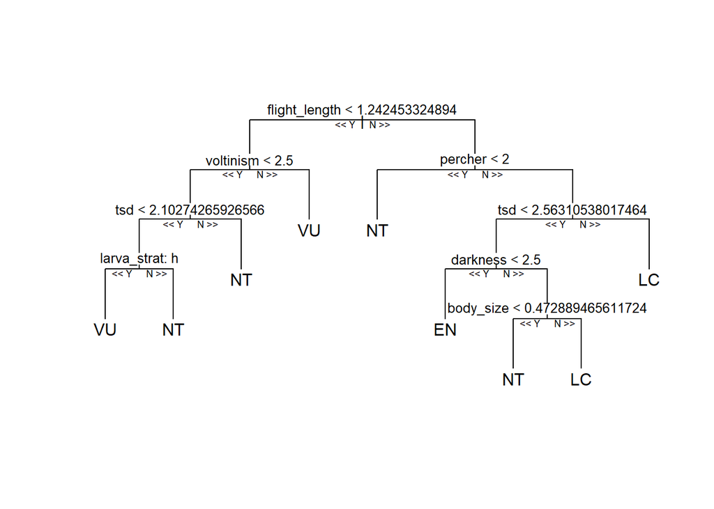

```r
reprtree:::plot.getTree(rf_status, k = 1)
```

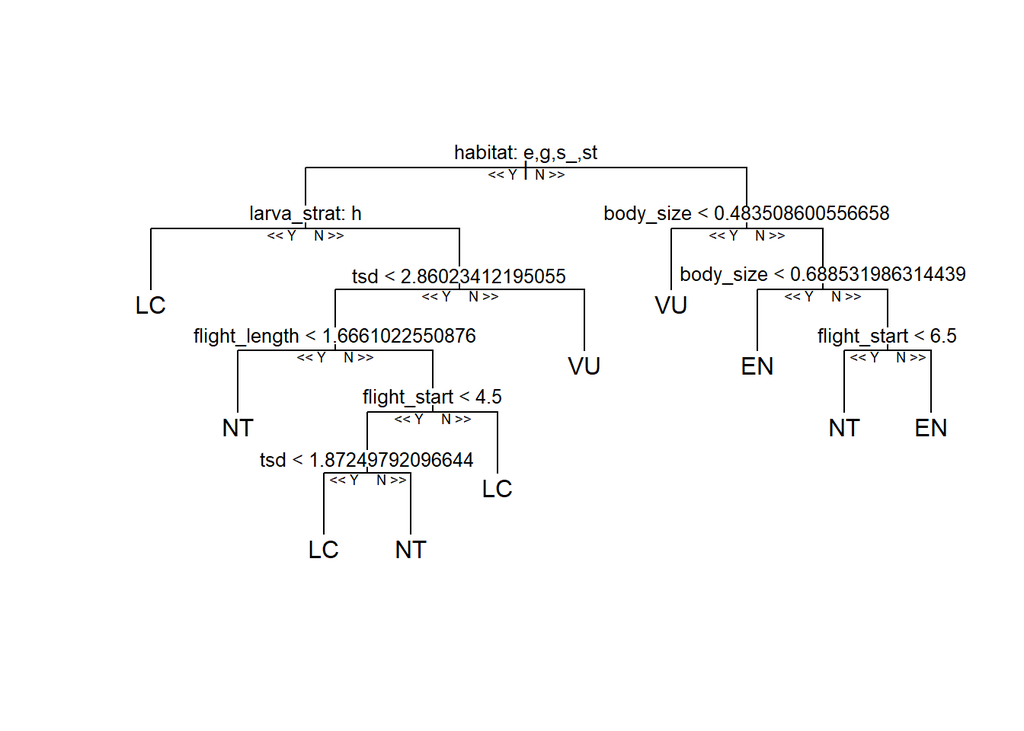

```r
reprtree:::plot.getTree(rf_status, k = 2)
```

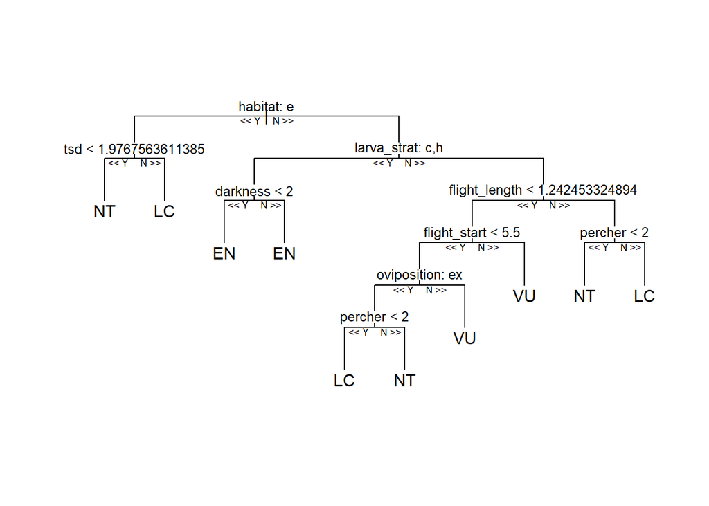

```r
reprtree:::plot.getTree(rf_status, k = 3)
```

This graph shows the evolution of the error rate (i.e. the proportion of incorrect classes attributions) with the number of trees used for prediction.

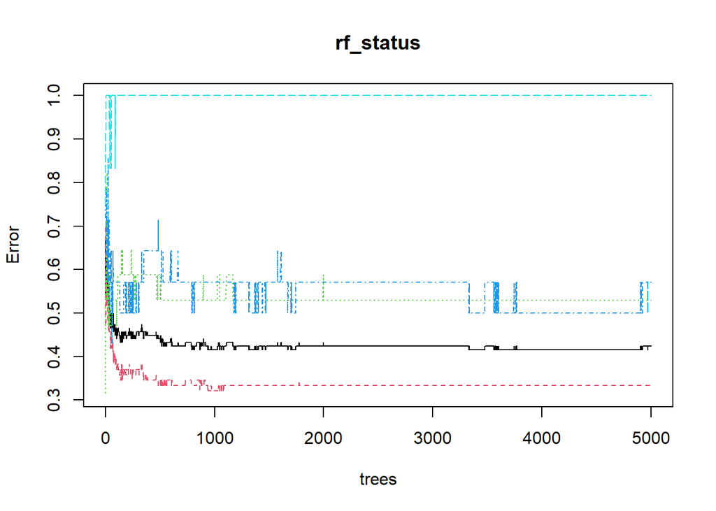

```r
plot(rf_status)
```

The error rates for each class are shows in colors, and the error for the out of bag predictions (= subset of the data that was not classified with this tree) is shown in black.

Errors decrease with the number of trees, indicating a good model convergence. However, model performance is mediocre (about 42 % error rate with all trees). This end state is visible in this graph, and also summarized below:

```r
rf_status
```

```
Call:
 randomForest(formula = status ~ ., data = df_status, ntree = 5000,      strata = df_status$status, sampsize = c(5, 5, 5, 3))
               Type of random forest: classification
                     Number of trees: 5000
No. of variables tried at each split: 3

        OOB estimate of  error rate: 42.37%
Confusion matrix:
   LC NT VU EN class.error
LC 54 11 11  5   0.3333333
NT  3  8  3  3   0.5294118
VU  4  2  6  2   0.5714286
EN  1  2  3  0   1.0000000
```

As this model cannot accurately predict the conservation status, I won’t look further in the model interpretation. Instead, I simplify the problem with a binary classification.

### 8.2 Binary status

```r
# Prepare data for lm
df_bstatus <- cbind(df_fac |> select(binary_status),
                    df_mvar)

# Remove factor levels
df_bstatus$binary_status <- as.character(df_bstatus$binary_status)
df_bstatus$binary_status <- factor(df_bstatus$binary_status,
                                  levels = unique(df_bstatus$binary_status))

# Look at imbalance
table(df_bstatus$binary_status)
```

```
Non-threatened     Threatened
            98             20
```

```r
rf_bstatus <- randomForest(
  formula = binary_status ~ .,
  data = df_bstatus,
  strata = df_bstatus$binary_status,
  importance = TRUE,
  sampsize  = c(10, 10),
  ntree = 5000,
  keep.forest = TRUE
)
```

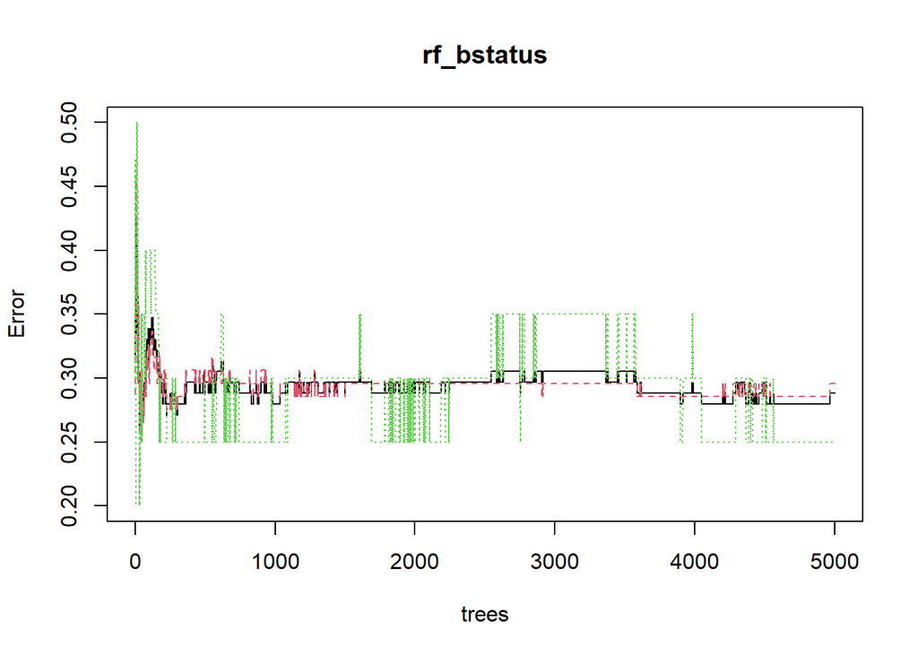

```r
plot(rf_bstatus)
```

This second model seems to converge, and reaches much more acceptable error rates (see below).

```r
rf_bstatus
```

```
Call:
 randomForest(formula = binary_status ~ ., data = df_bstatus,      strata = df_bstatus$binary_status, importance = TRUE, sampsize = c(10,          10), ntree = 5000, keep.forest = TRUE)
               Type of random forest: classification
                     Number of trees: 5000
No. of variables tried at each split: 3

        OOB estimate of  error rate: 28.81%
Confusion matrix:
               Non-threatened Threatened class.error
Non-threatened             69         29   0.2959184
Threatened                  5         15   0.2500000
```

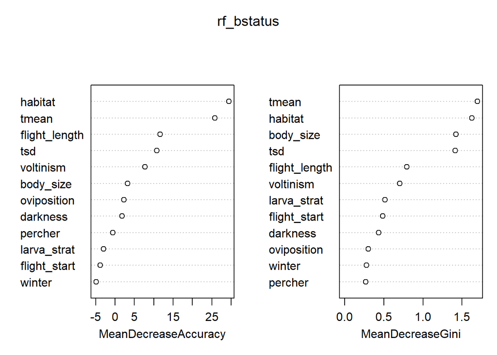

```r
varImpPlot(rf_bstatus)
```

The graph above gives variable importance to explain binary status, quantified with 2 criteria:

- Mean decrease accuracy (left) quantifies the decrease in accuracy of the model when the variable is permuted. If it is high, it means that this variable holds unique information, which is not correlated to other predictors.
- Mean Decrease Gini (right) quantifies the decrease in node impurity (measured with the Gini index), i.e. the classifications that can be attributed to the split done with this variable. It gives an idea of the importance of the variable, irrespective of whether it is correlated to other predictors or not.